# Movie recommendation

Shobhit Tiwari

## Synopsis

In this project we will predict missing ratings for all users and also recommend 10 movies for each user.We will use MovieLense dataset that for building our recommender.

Lets quickly load and explore the dataset

```r
data(MovieLense)
movMat<- as(MovieLense, "matrix")
dim(movMat)
```

```
## [1]  943 1664
```

```r
prod(dim(movMat)) - sum(is.na(movMat))
```

```
## [1] 99392
```

So we can see around 100k ratings are present in the dataset.

Let’s see the ratings by user 1

```r
head(movMat[1,])
```

```
##                                     Toy Story (1995)
##                                                    5
##                                     GoldenEye (1995)
##                                                    3
##                                    Four Rooms (1995)
##                                                    4
##                                    Get Shorty (1995)
##                                                    3
##                                       Copycat (1995)
##                                                    3
## Shanghai Triad (Yao a yao yao dao waipo qiao) (1995)
##                                                    5
```

Lets quickly see the histogram of ratings per user and movie

[figure not shown]

```r
## number of ratings per user
hist(rowCounts(MovieLense), main = "Ratings per movie")
```

[figure not shown]

```r
## number of ratings per movie
hist(colCounts(MovieLense), main = "Ratings per user")
```

We can see that very few movies are having high no of ratings and very few users have rated a large no of movies.

Now let us see a heatmap visualization of part of the dataset

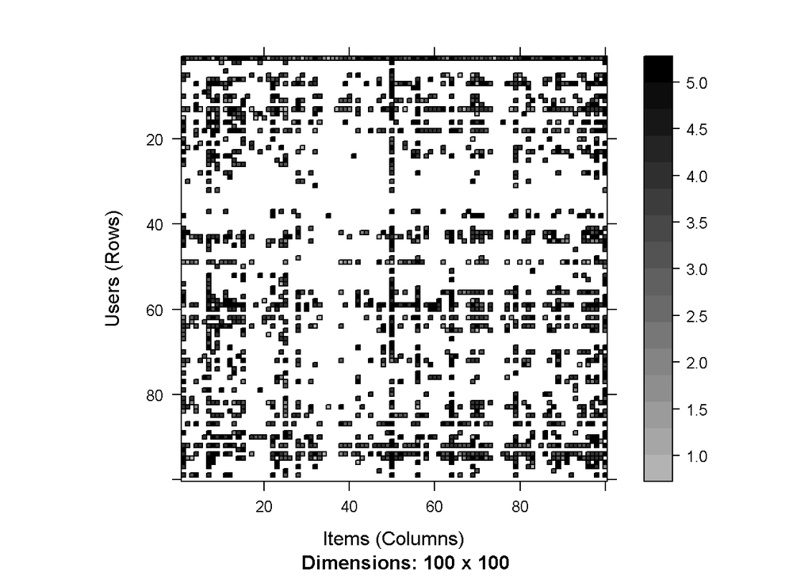

```r
## visualize part of the matrix
image(MovieLense[1:100,1:100])
```

Now we will split data into trian and test set using evaluation scheme function in the package.

```r
set.seed(1233)
e <- evaluationScheme(MovieLense, method="split", train=0.9, given=-5, goodRating=4)
```

We are splitting data into two parts training containing 90% of the users and 10% users are kept for test set with 5 ratings as unknown and rest as known.

First we will build a model using user based collaborative filtering. In UBCF rating for a user is predicted by finding similarity between user ratins and then taking weighted average of user raitngs to predict the missing ratings for the user.

Having users who give high (or low) ratings to all their movies might bias the results. We will normalize the ratings to minimize user bias.

```r
#Create UBCF Recommender Model. UBCF stands for User-Based Collaborative Filtering
UBCF_model <- Recommender(getData(e, "train"),
                                 method = "UBCF",
                                 param=list(normalize = "Z-score",
                                                 method="Cosine",
                                                 nn=50))
```

Now we will see top 10 movie recommendation for user 1

```r
firstUserPred <- predict(UBCF_model,
                 MovieLense[1,],
                 n=10, type = "topNList")
firstUserPred <- as(firstUserPred, "list")
# Get recommendation for first user only top 10 movies
firstUserPred[[1]]
```

```
##  [1] "Titanic (1997)"
##  [2] "L.A. Confidential (1997)"
##  [3] "Air Force One (1997)"
##  [4] "English Patient, The (1996)"
##  [5] "Apt Pupil (1998)"
##  [6] "Wag the Dog (1997)"
##  [7] "Rainmaker, The (1997)"
##  [8] "Mrs. Brown (Her Majesty, Mrs. Brown) (1997)"
##  [9] "Game, The (1997)"
## [10] "Postman, The (1997)"
```

Now predicting for the test set and checking accuracy of model

```r
recom <- predict(UBCF_model,
                 getData(e, "known"),
                 n=10, type = "ratings")
calcPredictionAccuracy(recom, getData(e, "unknown"))
```

```
##      RMSE       MSE       MAE
## 1.0445959 1.0911805 0.8641924
```

Secondly we will build an item based model. In this approach we predict ratings for a movie finding similar movies and taking weighted average of their ratings.

```r
IBCF_model <- Recommender(getData(e, "train"),
                                 method = "IBCF",
                                 param=list(normalize = "Z-score",
                                                 method="Cosine",
                                                 k=50))
```

Now we will see top 10 movie recommendation for user 1

```r
firstUserPred.IBCF <- predict(IBCF_model,
                 MovieLense[1,],
                 n=10, type = "topNList")
firstUserPred.IBCF <- as(firstUserPred.IBCF, "list")
# Get recommendation for first user only top 10 movies
firstUserPred.IBCF[[1]]
```

```
##  [1] "Bed of Roses (1996)"
##  [2] "FairyTale: A True Story (1997)"
##  [3] "Cop Land (1997)"
##  [4] "Judge Dredd (1995)"
##  [5] "Aladdin and the King of Thieves (1996)"
##  [6] "Cry, the Beloved Country (1995)"
##  [7] "Crossing Guard, The (1995)"
##  [8] "Courage Under Fire (1996)"
##  [9] "Streetcar Named Desire, A (1951)"
## [10] "Great Dictator, The (1940)"
```

Lets check on test set and calculate the RMSE

```r
recom.IBCF <- predict(IBCF_model,
                 getData(e, "known"),
                 n=10, type = "ratings")
calcPredictionAccuracy(recom.IBCF, getData(e, "unknown"))
```

```
##      RMSE       MSE       MAE
## 1.0811679 1.1689241 0.7946697
```

Lets build a matrix factorization model for recommendation using Alternating least squares model

```r
als_model <- Recommender(getData(e, "train"),
                                 method = "ALS",
                                 param=list(normalize = "Z-score",lambda=0.1, n_factors=200,
                                  n_iterations=10, seed = 214, verbose = FALSE))
```

Now predicting for the test set and checking accuracy of model

```r
recom_als <- predict(als_model,
                 getData(e, "known"),
                 n=10, type = "ratings")
calcPredictionAccuracy(recom_als, getData(e, "unknown"))
```

```
##      RMSE       MSE       MAE
##  3.646316 13.295621  3.481671
```

Now we will see top 10 movie recommendation for user 1

```r
firstUserals_Pred <- predict(als_model, newdata =  MovieLense[1,],n=10, type = "topNList")
firstUserals_Pred <- as(firstUserals_Pred, "list")
# Get recommendation for first user only top 10 movies
firstUserals_Pred[[1]]
```

```
##  [1] "Marlene Dietrich: Shadow and Light (1996) "
##  [2] "Very Natural Thing, A (1974)"
##  [3] "Walk in the Sun, A (1945)"
##  [4] "Office Killer (1997)"
##  [5] "Desert Winds (1995)"
##  [6] "King of New York (1990)"
##  [7] "New Age, The (1994)"
##  [8] "Close Shave, A (1995)"
##  [9] "L.A. Confidential (1997)"
## [10] "Saint of Fort Washington, The (1993)"
```